# Visualising the Development of openSenseMap.org in 2022

Jan Stenkamp

2023-03-08

> This vignette serves as an example on data wrangling & visualization with `opensensmapr`, `dplyr` and `ggplot2`.

```r
# required packages:
library(opensensmapr) # data download
library(dplyr)        # data wrangling
library(ggplot2)      # plotting
library(lubridate)    # date arithmetic
library(zoo)          # rollmean()
```

openSenseMap.org has grown quite a bit in the last years; it would be interesting to see how we got to the current 11448 sensor stations, split up by various attributes of the boxes.

While `opensensmapr` provides extensive methods of filtering boxes by attributes on the server, we do the filtering within R to save time and gain flexibility.

So the first step is to retrieve *all the boxes*.

```r
# if you want to see results for a specific subset of boxes,
# just specify a filter such as grouptag='ifgi' here

# boxes = osem_boxes(cache = '.')
boxes = readRDS('boxes_precomputed.rds')  # read precomputed file to save resources
```

# Introduction

In the following we just want to have a look at the boxes created in 2022, so we filter for them.

```r
boxes = filter(boxes, locationtimestamp >= "2022-01-01" & locationtimestamp <="2022-12-31")
summary(boxes) -> summary.data.frame
```

```
## boxes total: 2107
##
## boxes by exposure:
##  indoor  mobile outdoor unknown
##     524     200    1382       1
##
## boxes by model:
##                   custom          hackair_home_v2             homeEthernet
##                      931                        5                        5
##    homeEthernetFeinstaub           homeV2Ethernet  homeV2EthernetFeinstaub
##                        2                        5                        5
##               homeV2Lora               homeV2Wifi      homeV2WifiFeinstaub
##                       58                      220                      114
##                 homeWifi        homeWifiFeinstaub        luftdaten_pms1003
##                       14                       17                        0
## luftdaten_pms1003_bme280        luftdaten_pms3003 luftdaten_pms3003_bme280
##                        1                        0                        0
##        luftdaten_pms5003 luftdaten_pms5003_bme280        luftdaten_pms7003
##                        2                        8                        0
## luftdaten_pms7003_bme280         luftdaten_sds011  luftdaten_sds011_bme280
##                        8                       28                      462
##  luftdaten_sds011_bmp180   luftdaten_sds011_dht11   luftdaten_sds011_dht22
##                       27                        7                      188
##
## $last_measurement_within
##    1h    1d   30d  365d never
##     0     0   851  1542   497
##
## oldest box: 2020-02-29 23:00:31 (Kirchardt 1)
## newest box: 2022-12-30 09:19:46 (Balkon)
##
## sensors per box:
##    Min. 1st Qu.  Median    Mean 3rd Qu.    Max.
##   1.000   3.000   5.000   4.978   6.000  29.000
```

Another feature of interest is the spatial distribution of the boxes: `plot()` can help us out here. This function requires a bunch of optional dependencies though.

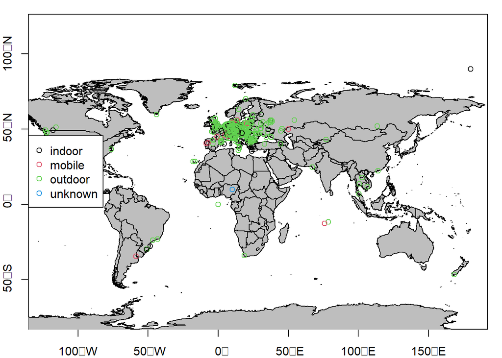

```r
plot(boxes)
```

But what do these sensor stations actually measure? Lets find out. `osem_phenomena()` gives us a named list of of the counts of each observed phenomenon for the given set of sensor stations:

```r
phenoms = osem_phenomena(boxes)
str(phenoms)
```

```
## List of 966
##  $ Temperatur                             : int 1520
##  $ rel. Luftfeuchte                       : int 1289
##  $ PM10                                   : int 1069
##  $ PM2.5                                  : int 1068
##  $ Luftdruck                              : int 994
##  $ Beleuchtungsstärke                     : int 282
##  $ UV-Intensität                          : int 282
##  $ VOC                                    : int 224
##  $ Lufttemperatur                         : int 208
##  $ CO₂                                    : int 178
##  $ Bodenfeuchte                           : int 170
##  $ Temperature                            : int 167
##  $ Luftfeuchte                            : int 134
##  $ Lautstärke                             : int 131
```

[output cut: 86 more lines]

Thats quite some noise there, with many phenomena being measured by a single sensor only, or many duplicated phenomena due to slightly different spellings. We should clean that up, but for now let’s just filter out the noise and find those phenomena with high sensor numbers:

```r
phenoms[phenoms > 50]
```

```
## $Temperatur
## [1] 1520
##
## $`rel. Luftfeuchte`
## [1] 1289
##
## $PM10
## [1] 1069
##
## $PM2.5
## [1] 1068
##
## $Luftdruck
## [1] 994
##
## $Beleuchtungsstärke
## [1] 282
##
## $`UV-Intensität`
## [1] 282
##
## $VOC
## [1] 224
##
## $Lufttemperatur
## [1] 208
##
## $`CO₂`
## [1] 178
##
## $Bodenfeuchte
## [1] 170
##
## $Temperature
## [1] 167
##
## $Luftfeuchte
## [1] 134
##
## $Lautstärke
```

[output cut: 19 more lines]

```
##
## $`rel. Luftfeuchte SCD30`
## [1] 107
##
## $Pressure
## [1] 97
##
## $Luftfeuchtigkeit
## [1] 62
##
## $PM01
## [1] 57
##
## $Bodentemperatur
## [1] 55
```

# Plot count of boxes by time

By looking at the `createdAt` attribute of each box we know the exact time a box was registered. Because of some database migration issues the `createdAt` values are mostly wrong (~80% of boxes created 2022-03-30), so we are using the `timestamp` attribute of the `currentlocation` which should in most cases correspond to the creation date.

With this approach we have no information about boxes that were deleted in the meantime, but that’s okay for now.

## …and exposure

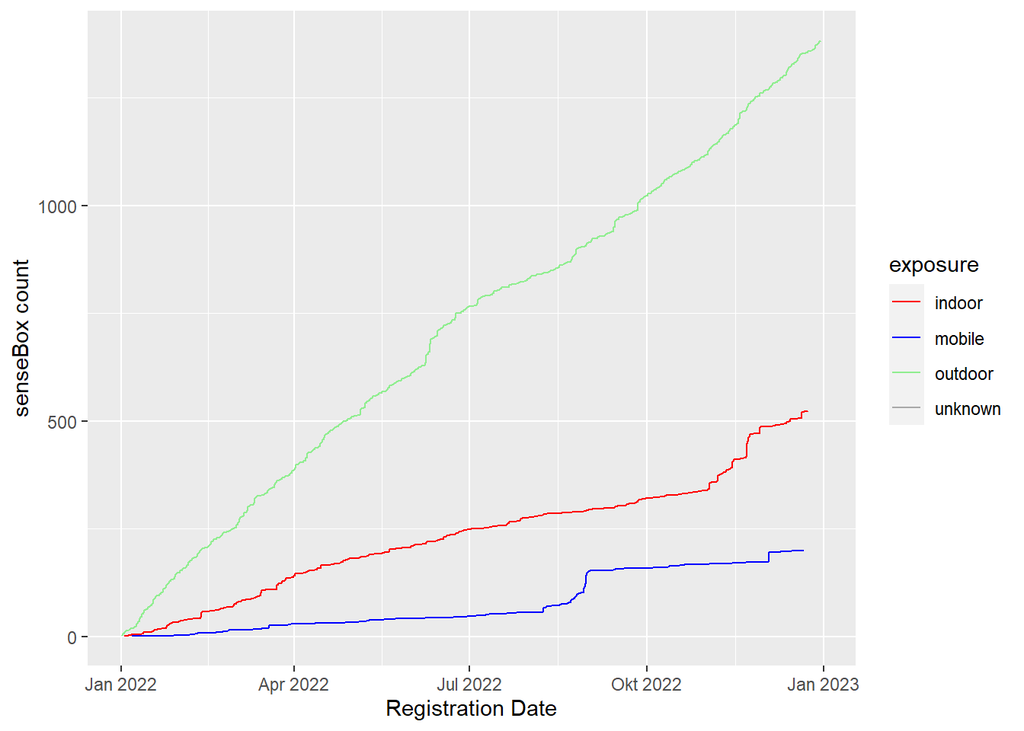

```r
exposure_counts = boxes %>%
  group_by(exposure) %>%
  mutate(count = row_number(locationtimestamp))

exposure_colors = c(indoor = 'red', outdoor = 'lightgreen', mobile = 'blue', unknown = 'darkgrey')
ggplot(exposure_counts, aes(x = locationtimestamp, y = count, colour = exposure)) +
  geom_line() +
  scale_colour_manual(values = exposure_colors) +
  xlab('Registration Date') + ylab('senseBox count')
```

Let’s have a quick summary:

```r
exposure_counts %>%
  summarise(
    oldest = min(locationtimestamp),
    newest = max(locationtimestamp),
    count = max(count)
  ) %>%
  arrange(desc(count))
```

| exposure | oldest | newest | count |
| --- | --- | --- | --- |
| outdoor | 2022-01-01 11:59:16 | 2022-12-30 09:19:46 | 1382 |
| indoor | 2022-01-02 11:06:08 | 2022-12-23 20:46:45 | 524 |
| mobile | 2022-01-06 13:20:00 | 2022-12-21 21:35:16 | 200 |
| unknown | 2022-03-01 07:04:30 | 2022-03-01 07:04:30 | 1 |

## …and grouptag

We can try to find out where the increases in growth came from, by analysing the box count by grouptag.

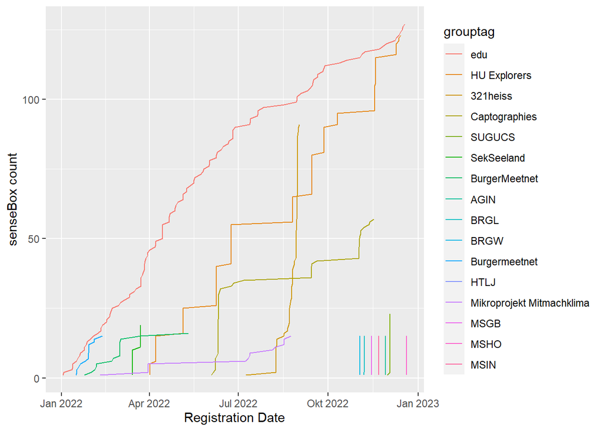

```r
grouptag_counts = boxes %>%
  group_by(grouptag) %>%
  # only include grouptags with 15 or more members
  filter(length(grouptag) >= 15 & !is.na(grouptag) & grouptag != '') %>%
  mutate(count = row_number(locationtimestamp))

# helper for sorting the grouptags by boxcount
sortLvls = function(oldFactor, ascending = TRUE) {
  lvls = table(oldFactor) %>% sort(., decreasing = !ascending) %>% names()
  factor(oldFactor, levels = lvls)
}
grouptag_counts$grouptag = sortLvls(grouptag_counts$grouptag, ascending = FALSE)

ggplot(grouptag_counts, aes(x = locationtimestamp, y = count, colour = grouptag)) +
  geom_line(aes(group = grouptag)) +
  xlab('Registration Date') + ylab('senseBox count')
```

```r
grouptag_counts %>%
  summarise(
    oldest = min(locationtimestamp),
    newest = max(locationtimestamp),
    count = max(count)
  ) %>%
  arrange(desc(count))
```

| grouptag | oldest | newest | count |
| --- | --- | --- | --- |
| edu | 2022-01-02 11:06:08 | 2022-12-18 12:38:27 | 127 |
| HU Explorers | 2022-04-01 09:07:41 | 2022-12-14 10:11:34 | 123 |
| 321heiss | 2022-07-09 01:29:37 | 2022-09-01 06:27:35 | 91 |
| Captographies | 2022-06-03 11:25:27 | 2022-11-16 13:26:39 | 57 |
| SUGUCS | 2022-11-30 15:25:32 | 2022-12-03 10:11:41 | 23 |
| SekSeeland | 2022-03-14 13:17:17 | 2022-03-22 20:23:58 | 19 |
| BurgerMeetnet | 2022-01-24 15:33:19 | 2022-05-10 21:22:35 | 16 |
| AGIN | 2022-11-28 17:33:12 | 2022-11-28 17:42:18 | 15 |
| BRGL | 2022-11-06 19:23:43 | 2022-11-06 22:08:36 | 15 |
| BRGW | 2022-11-02 10:28:52 | 2022-11-02 13:32:12 | 15 |
| Burgermeetnet | 2022-01-15 20:43:16 | 2022-02-11 17:59:05 | 15 |
| HTLJ | 2022-11-21 22:04:17 | 2022-11-21 22:05:47 | 15 |
| Mikroprojekt Mitmachklima | 2022-02-09 10:28:40 | 2022-08-23 13:14:11 | 15 |
| MSGB | 2022-11-14 09:08:57 | 2022-11-14 10:19:24 | 15 |
| MSHO | 2022-12-20 09:28:40 | 2022-12-20 10:01:38 | 15 |
| MSIN | 2022-11-21 17:02:39 | 2022-11-21 23:06:22 | 15 |

# Plot rate of growth and inactivity per week

First we group the boxes by `locationtimestamp` into bins of one week:

```r
bins = 'week'
mvavg_bins = 6

growth = boxes %>%
  mutate(week = cut(as.Date(locationtimestamp), breaks = bins)) %>%
  group_by(week) %>%
  summarize(count = length(week)) %>%
  mutate(event = 'registered')
```

We can do the same for `updatedAt`, which informs us about the last change to a box, including uploaded measurements. As a lot of boxes were “updated” by the database migration, many of them are updated at 2022-03-30, so we try to use the `lastMeasurement` attribute instead of `updatedAt`. This leads to fewer boxes but also automatically excludes boxes which were created but never made a measurement.

This method of determining inactive boxes is fairly inaccurate and should be considered an approximation, because we have no information about intermediate inactive phases. Also deleted boxes would probably have a big impact here.

```r
inactive = boxes %>%
  # remove boxes that were updated in the last two days,
  # b/c any box becomes inactive at some point by definition of updatedAt
  filter(lastMeasurement < now() - days(2)) %>%
  mutate(week = cut(as.Date(lastMeasurement), breaks = bins)) %>%
  filter(as.Date(week) > as.Date("2021-12-31")) %>%
  group_by(week) %>%
  summarize(count = length(week)) %>%
  mutate(event = 'inactive')
```

Now we can combine both datasets for plotting:

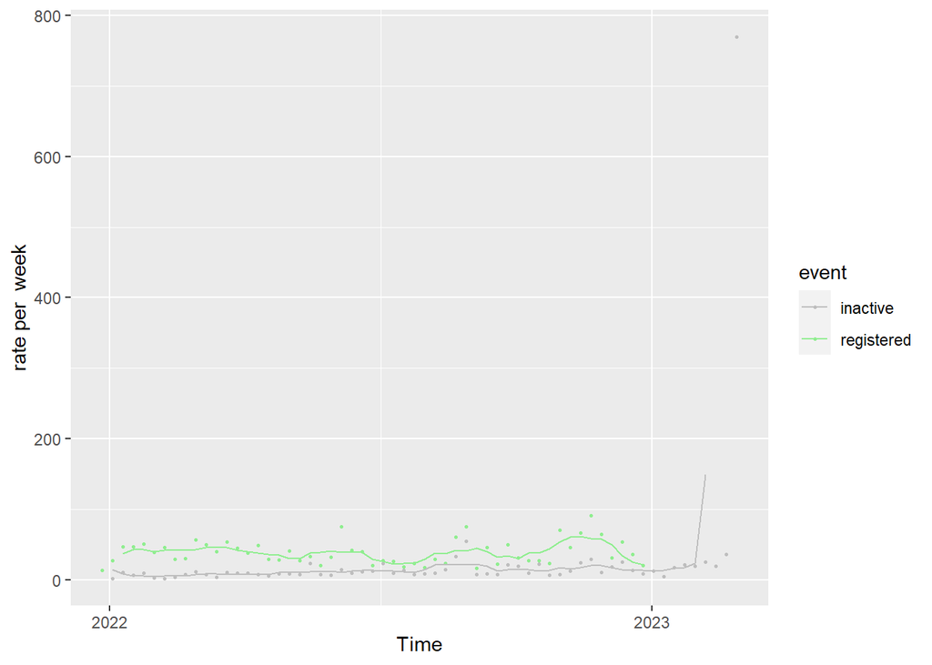

```r
boxes_by_date = bind_rows(growth, inactive) %>% group_by(event)

ggplot(boxes_by_date, aes(x = as.Date(week), colour = event)) +
  xlab('Time') + ylab(paste('rate per ', bins)) +
  scale_x_date(date_breaks="years", date_labels="%Y") +
  scale_colour_manual(values = c(registered = 'lightgreen', inactive = 'grey')) +
  geom_point(aes(y = count), size = 0.5) +
  # moving average, make first and last value NA (to ensure identical length of vectors)
  geom_line(aes(y = rollmean(count, mvavg_bins, fill = list(NA, NULL, NA))))
```

And see in which weeks the most boxes become (in)active:

```r
boxes_by_date %>%
  filter(count > 50) %>%
  arrange(desc(count))
```

| week | count | event |
| --- | --- | --- |
| 2023-02-27 | 769 | inactive |
| 2022-11-21 | 92 | registered |
| 2022-06-06 | 76 | registered |
| 2022-08-29 | 76 | registered |
| 2022-10-31 | 71 | registered |
| 2022-11-14 | 67 | registered |
| 2022-11-28 | 65 | registered |
| 2022-08-22 | 61 | registered |
| 2022-02-28 | 57 | registered |
| 2022-08-29 | 55 | inactive |
| 2022-03-21 | 54 | registered |
| 2022-12-12 | 54 | registered |
| 2022-01-24 | 51 | registered |

# Plot duration of boxes being active

While we are looking at `locationtimestamp` and `lastMeasurement`, we can also extract the duration of activity of each box, and look at metrics by exposure and grouptag once more:

## …by exposure

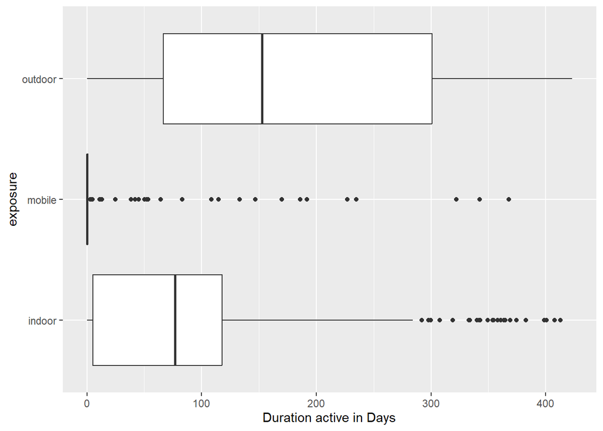

```r
durations = boxes %>%
  group_by(exposure) %>%
  filter(!is.na(lastMeasurement)) %>%
  mutate(duration = difftime(lastMeasurement, locationtimestamp, units='days')) %>%
  filter(duration >= 0)

ggplot(durations, aes(x = exposure, y = duration)) +
  geom_boxplot() +
  coord_flip() + ylab('Duration active in Days')
```

The time of activity averages at only 148 days, though there are boxes with 423 days of activity, spanning a large chunk of openSenseMap’s existence.

## …by grouptag

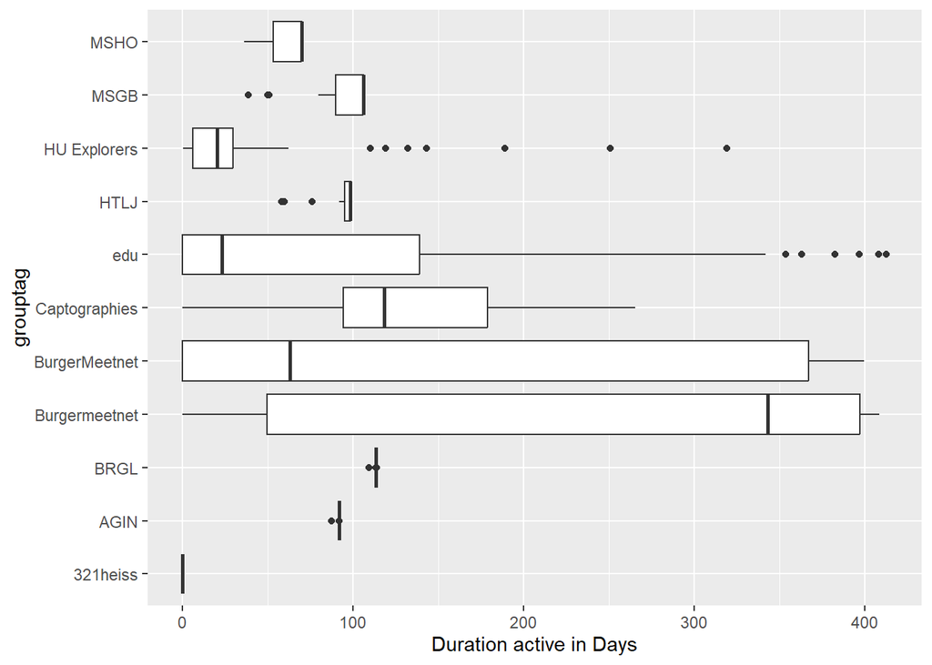

```r
durations = boxes %>%
  filter(!is.na(lastMeasurement)) %>%
  group_by(grouptag) %>%
  # only include grouptags with 20 or more members
  filter(length(grouptag) >= 15 & !is.na(grouptag) & !is.na(lastMeasurement)) %>%
  mutate(duration = difftime(lastMeasurement, locationtimestamp, units='days')) %>%
  filter(duration >= 0)

ggplot(durations, aes(x = grouptag, y = duration)) +
  geom_boxplot() +
  coord_flip() + ylab('Duration active in Days')
```

```r
durations %>%
  summarize(
    duration_avg = round(mean(duration)),
    duration_min = round(min(duration)),
    duration_max = round(max(duration)),
    oldest_box = round(max(difftime(now(), locationtimestamp, units='days')))
  ) %>%
  arrange(desc(duration_avg))
```

| grouptag | duration_avg | duration_min | duration_max | oldest_box |
| --- | --- | --- | --- | --- |
| Burgermeetnet | 238 days | 0 days | 409 days | 417 days |
| BurgerMeetnet | 171 days | 0 days | 400 days | 408 days |
| Captographies | 125 days | 0 days | 266 days | 276 days |
| BRGL | 113 days | 109 days | 114 days | 122 days |
| MSGB | 92 days | 39 days | 106 days | 114 days |
| AGIN | 91 days | 87 days | 92 days | 100 days |
| HTLJ | 91 days | 58 days | 99 days | 107 days |
| edu | 89 days | 0 days | 413 days | 421 days |
| MSHO | 61 days | 36 days | 70 days | 78 days |
| HU Explorers | 44 days | 0 days | 319 days | 341 days |
| 321heiss | 0 days | 0 days | 0 days | 243 days |

The time of activity averages at only 72 days, though there are boxes with 413 days of activity, spanning a large chunk of openSenseMap’s existence.

## …by year of registration

This is less useful, as older boxes are active for a longer time by definition. If you have an idea how to compensate for that, please send a [Pull Request](https://github.com/sensebox/opensensmapr/pulls)!

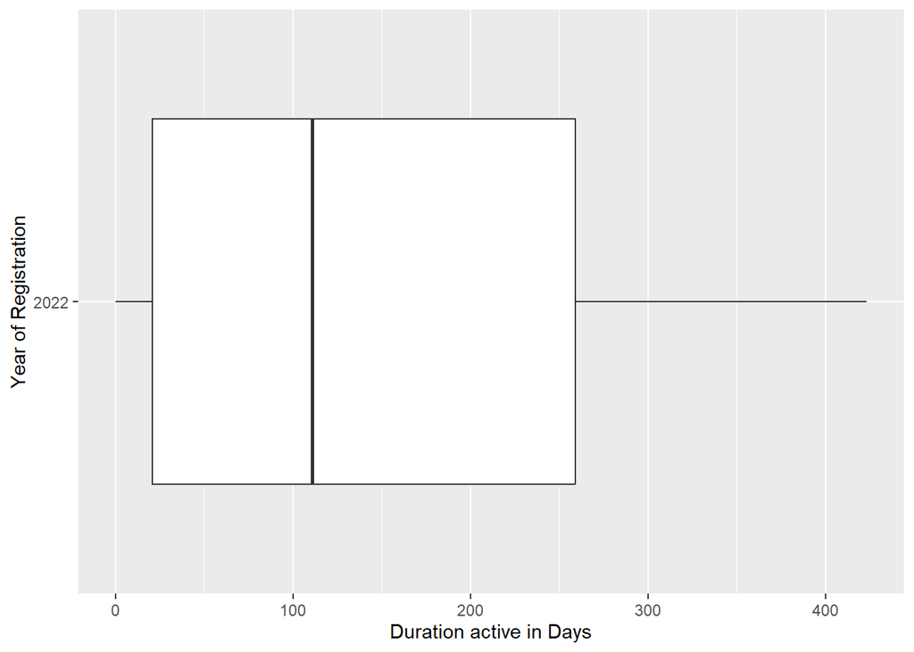

```r
# NOTE: boxes older than 2016 missing due to missing updatedAt in database
duration = boxes %>%
  mutate(year = cut(as.Date(locationtimestamp), breaks = 'year')) %>%
  group_by(year) %>%
  filter(!is.na(lastMeasurement)) %>%
  mutate(duration = difftime(lastMeasurement, locationtimestamp, units='days')) %>%
  filter(duration >= 0)

ggplot(duration, aes(x = substr(as.character(year), 0, 4), y = duration)) +
  geom_boxplot() +
  coord_flip() + ylab('Duration active in Days') + xlab('Year of Registration')
```

# More Visualisations

Other visualisations come to mind, and are left as an exercise to the reader. If you implemented some, feel free to add them to this vignette via a [Pull Request](https://github.com/sensebox/opensensmapr/pulls).

- growth by phenomenon
- growth by location -> (interactive) map
- set inactive rate in relation to total box count
- filter timespans with big dips in growth rate, and extrapolate the amount of senseBoxes that could be on the platform today, assuming there were no production issues ;)